[figure not shown]

BR-2

General Description

BRAKE

1. General Description

A: SPECIFICATION

NOTE:

Refer to “PARKING BRAKE” for parking brake specifications. <Ref. to PB-2, SPECIFICATION, General De-

scription.>

1. FRONT DISC BRAKE

• Except for STI model

• STI model

Item Specification

Size 17-inch

Type

Floating 2-POT piston type

Ventilated disc

Effective cylinder diameter mm (in)

42.8 × 2

(1.685 × 2)

Pad size

(Length × Width × Thickness)

mm (in)

130.0 × 53.5 × 11.0

(5.118 × 2.106 × 0.433)

Pad thickness mm (in)

Standard 11 (0.43)

Limit 1.5 (0.059)

Effective disc diameter mm (in) 261 (10.28)

Rotor size

(O.D. × Thickness)

mm (in)

30 × 316

(1.18 × 12.44)

Disc thickness mm (in)

Standard 30 (1.18)

Limit 28 (1.10)

Disc runout mm (in)

Standard —

Limit 0.05 (0.0020)

Clearance adjustment Automatic adjustment

Item Specification

Size 17-inch

Type

Opposed 4-POT piston type

Ventilated disc

(Brembo)

Effective cylinder diameter mm (in)

40.0 × 2, 46.0 × 2

(1.575 × 2, 1.811 × 2)

Pad size

(Length × Width × Thickness)

mm (in)

131.8 × 60.5 × 8.9

(5.189 × 2.382 × 0.35)

Pad thickness mm (in)

Standard 8.9 (0.35)

Limit 1.2 (0.047)

Effective disc diameter mm (in) 268 (10.55)

Rotor size

(O.D. × Thickness)

mm (in) 30 × 326 (1.18 × 12.83)

Disc thickness mm (in)

Standard 30 (1.18)

Limit 28 (1.10)

Disc runout mm (in)

Standard —

Limit 0.075 (0.0030)

Clearance adjustment Automatic adjustment

[figure not shown]

BR-3

General Description

BRAKE

2. REAR DISC BRAKE

• Except for STI model

• STI model

3. MASTER CYLINDER

Item Specification

Size 15-inch

Type

Floating 1-POT piston type

Solid disc

Effective cylinder diameter mm (in) 38.1 (1.500)

Pad size

(Length × Width × Thickness)

mm (in)

92.0 × 33.0 × 9.0

(3.622 × 1.299 × 0.354)

Pad thickness mm (in)

Standard 9.0 (0.354)

Limit 1.5 (0.059)

Effective disc diameter mm (in) 250 (9.84)

Rotor size

(O.D. × Thickness)

mm (in)

10 × 286

Disc thickness mm (in)

Standard 10 (0.39)

Limit 8.5 (0.335)

Disc runout mm (in)

Standard —

Limit 0.05 (0.0020)

Clearance adjustment Automatic adjustment

Item Specification

Size 17-inch

Type

Opposed 2-POT piston type

Ventilated disc

(Brembo)

Effective cylinder diameter mm (in)

40.0 × 2

(1.575 × 2)

Pad size

(Length × Width × Thickness)

mm (in)

76.8 × 45.0 × 9.0

(3.024 × 1.772 × 0.354)

Pad thickness mm (in)

Standard 9.0 (0.354)

Limit 1.2 (0.047)

Effective disc diameter mm (in) 268 (10.55)

Rotor size

(O.D. × Thickness)

mm (in)

20 × 316

(0.79 × 12.44 )

Disc thickness mm (in)

Standard 20 (0.79)

Limit 18 (0.71)

Disc runout mm (in)

Standard —

Limit 0.070 (0.0028)

Clearance adjustment Automatic adjustment

Item Specification

Type Tandem

Effective diameter mm (in) 25.40 (1.00)

Reservoir type Sealed type

Brake fluid

reservoir capacity

cm

3

(cu in) 240 (14.64)

[figure not shown]

BR-4

General Description

BRAKE

4. BRAKE BOOSTER

5. BRAKE LINE, BRAKE PEDAL AND BRAKE FLUID

CAUTION:

• Avoid mixing brake fluid of different brands to prevent fluid performance from degrading.

• When filling with brake fluid, be careful not to allow any dust to enter the reservoir.

• Use new SUBARU genuine brake fluid when replacing or refilling the fluid.

Item Specification

Type Vacuum suspended

Effective diameter mm (in) 208 + 229 (8.19 + 9.02)

Brake fluid pressure Brake pedal force N (kgf, lbf) Fluid pressure kPa (kgf/cm

2

, psi)

When engine is stopped

147 (15, 33) 471 (4.8,68.3)

294 (30, 66) 1,385 (14.1, 200.8)

When engine is running and vacuum pressure is

at 66.7 kPa (500 mmHg, 19.69 inHg)

147 (15, 33) 4,880 (49.8, 707.6)

294 (30, 66) 9,750 (99.4, 1413.7)

Item Specification

Brake line Dual circuit system

Brake pedal

Type Suspended type

Free play mm (in)

0.5 — 2 (0.020 — 0.079)

[When pulling the brake pedal upward with a force of less

than 10 N (1 kgf, 2 lbf)]

Brake fluid FMVSS No. 116, DOT3, or DOT4

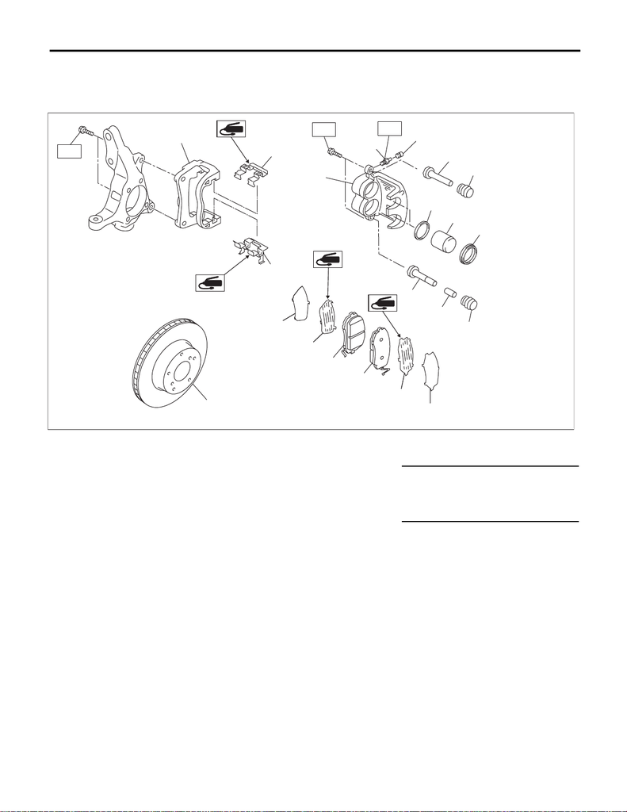

BR-5

General Description

BRAKE

B: COMPONENT

1. FRONT DISC BRAKE

• Except for STI model

(1) Support - front disc brake (9) Piston - disc brake (17) Disc rotor (ventilated type)

(2) Pad clip - front brake (10) Piston boot

(3) Caliper body (11) Lock pin - front brake (silver) Tightening torque: N·m (kgf-m, ft-lb)

(4) Bleeder - screw (12) Lock pin - bushing T1: 8 (0.8, 5.9)

(7) Pin boot (15) Pad - disc brake front outer

(8) Piston seal (16) Pad - disc brake front inner

BR-01254

(17)

(2)

(1)

T3

(3)

(4)

(8)

(9)

(10)

T2

T1

(7)

(12)

(11)

(6)

(7)

(5)

(13)

(13)

(14)

(14)

(15)

(16)

(2)

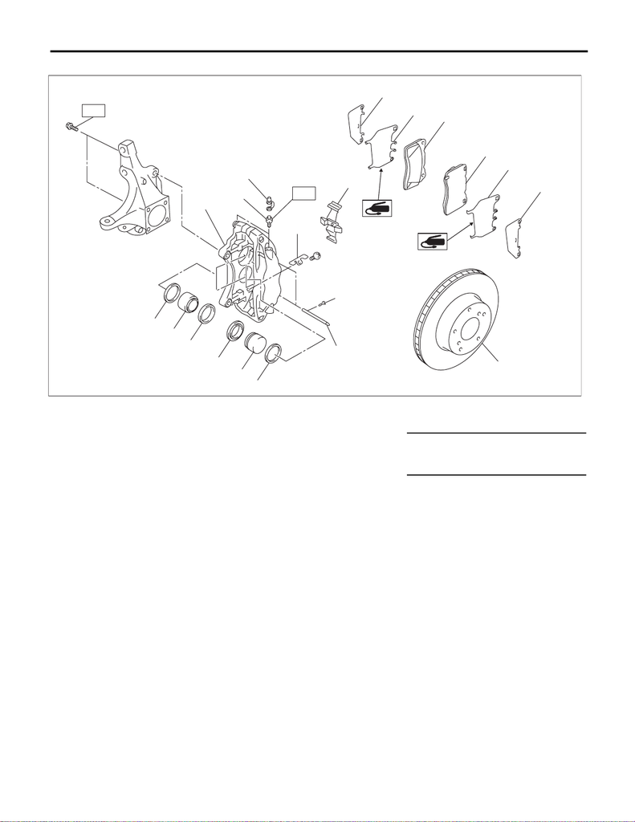

BR-6

General Description

BRAKE

• STI model

(1) Caliper body (8) Pad - disc brake front inner (15) Piston boot

(2) Bleeder - screw (9) Pad - disc brake front outer

(3) Cap - bleeder (10) Disc rotor (ventilated type) Tightening torque: N·m (kgf-m, ft-lb)

(4) Guide plate (11) Clip - slide pin T1: 20 (2.0, 14.8)

(5) Cross spring (12) Pin - disc brake T2: 155 (15.8, 114.3)

(6) Shim - disc brake front outer (13) Piston seal

(7) Shim - disc brake front inner (14) Piston - disc brake

BR-01255

T1

T2

(5)

(4)

(6)

(6)

(14)

(14)

(2)

(1)

(13)

(13)

(11)

(10)

(9)

(8)

(7)

(7)

(3)

(12)

(15)

(15)

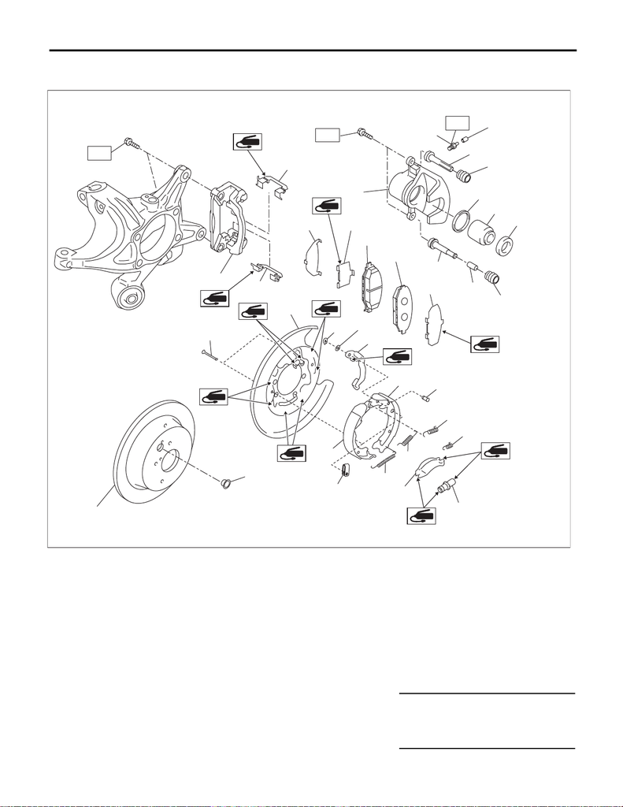

BR-7

General Description

BRAKE

2. REAR DISC BRAKE

• Except for STI model

(1) Support - rear disc brake (14) Shim - disc brake rear inner (27) Adjuster ASSY - rear brake

(2) Pad clip - rear brake (15) Pad - disc brake rear inner (28) Strut - brake

(3) Bleeder - screw (16) Pad - disc brake rear outer (29) Spring - primary shoe return

(4) Cap - bleeder (17) Shim - disc brake rear outer and

inner

(30) Spring - adjuster

(5) Guide pin - rear brake (black) (18) Pin - shoe hold-down (31) Spring - shoe clamp

(6) Pin boot (19) Back plate - rear brake (32) Parking brake shoe (primary)

(7) Caliper body (20) Retainer - rear brake (33) Adjusting hole cover

(8) Piston seal (21) Spring washer - rear brake (34) Disc rotor (solid type)

(9) Piston - disc brake (22) Parking lever - rear

(10) Piston boot (23) Parking brake shoe (secondary) Tightening torque: N·m (kgf-m, ft-lb)

(11) Lock pin - rear brake (silver) (24) Pin - parking lever T1: 8 (0.8, 5.9)

(12) Lock pin - bushing (25) Spring - secondary shoe return T2: 27 (2.8, 19.9)

(13) Shim - disc brake rear outer (26) Spring - strut T3: 66 (6.7, 48.7)

BR-01256

25

(18)

(2)

(19)

(20)

(21)

(22)

(24)

(23)

(32)

(25)

(26)

(27)

(28)

(29)

(30)

(31)

(2)

(14)

(15)

(16)

(17)

(1)

(7)

(3)

(5)

(6)

(8)

(9)

(10)

(11)

(12)

(6)

(34)

(33)

(4)

T3

T2

T1

(13)

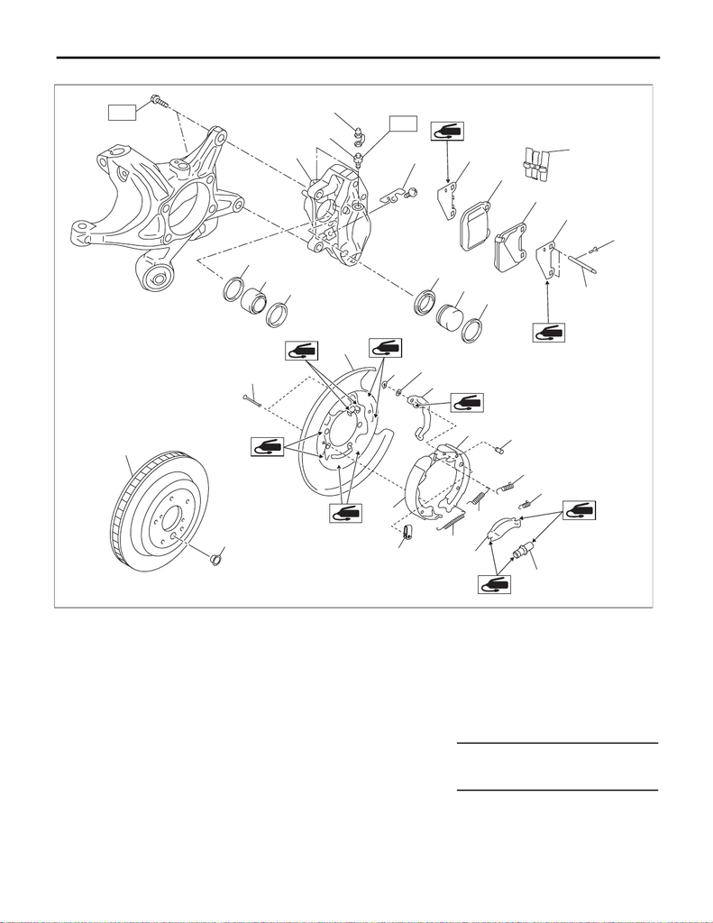

BR-8

General Description

BRAKE

• STI model

(1) Caliper body (13) Piston boot (25) Spring - primary shoe return

(2) Bleeder - screw (14) Pin - shoe hold-down (26) Spring - adjuster

(3) Cap - bleeder (15) Back plate - rear brake (27) Spring - shoe clamp

(4) Guide plate (16) Retainer - rear brake (28) Parking brake shoe (primary)

(5) Cross spring (17) Spring washer - rear brake (29) Adjusting hole cover

(6) Shim - disc brake rear outer and

inner

(18) Parking lever - rear (30) Disc rotor (solid type)

(7) Pad - disc brake rear inner (19) Parking brake shoe (secondary)

(8) Pad - disc brake rear outer (20) Pin - parking lever Tightening torque: N·m (kgf-m, ft-lb)

(9) Clip - slide pin (21) Spring - secondary shoe return T1: 20 (2.0, 14.8)

(10) Pin - disc brake (22) Spring - strut T2: 65 (6.6, 47.9)

BR-01257

T2

25

(14)

(15)

(16)

(17)

(18)

(20)

(19)

(28)

(21)

(22)

(23)

(24)

(25)

(26)

(27)

T1

(13)

(13)

(5)

(12)

(12)

(4)

(2)

(1)

(7)

(8)

(6)

(6)

(10)

(9)

(11)

(11)

(3)

(30)

(29)

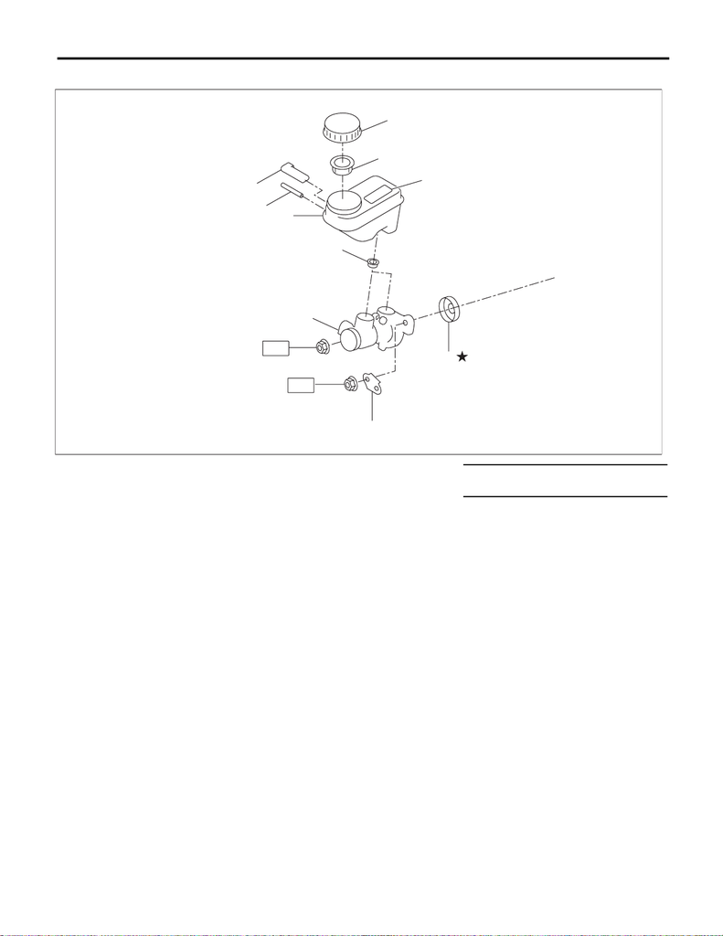

BR-9

General Description

BRAKE

3. MASTER CYLINDER

(1) Cap - reservoir tank (6) Cylinder body ASSY Tightening torque: N·m (kgf-m, ft-lb)

(2) Filter - master cylinder (7) Seal T: 13 (1.3, 9.6)

(3) Caution label (model with caution

label)

(8) Reservoir tank

(4) Seal sub ASSY (9) Pin

(5) Bracket - master cylinder (10) Level - indicator

(8)

(6)

(7)

(9)

(10)

(4)

T

T

(1)

(2)

(5)

(3)

BR-01046

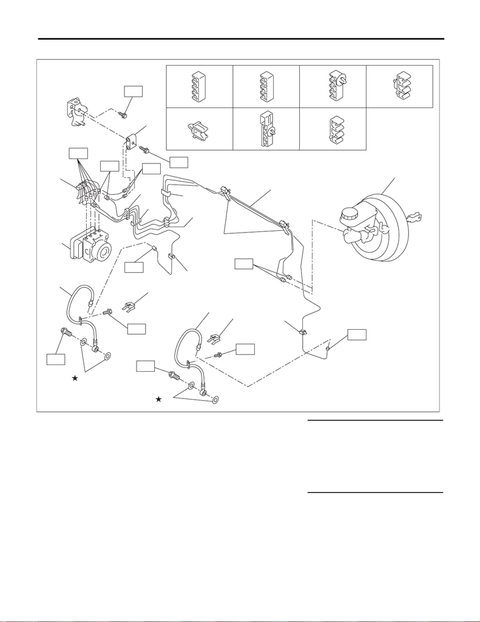

BR-10

General Description

BRAKE

4. FRONT BRAKE PIPES AND HOSES

(1) Connector - two-way (5) Gasket Tightening torque: N·m (kgf-m, ft-lb)

(2) VDC control module and hydraulic

control unit (VDCCM&H/U)

(6) Clamp T1: 15 (1.5, 11.1)

(3) Front brake pipe ASSY (7) Front brake hose LH T2: 18 (1.8, 13.3)

(4) Master cylinder ASSY (8) Front brake hose RH T3: 19 ( 1.9, 14.0)

T4: 26 ( 2.7, 19.2)

T5: 33 (3.4, 24.3)

BR-01377

a

b

ef

c

d

g

f

a

(2)

(3)

(1)

(4)

(7)

(6)

(6)

(5)

(5)

(8)

T1

T1

T2

T4

T4

T1

T1

T3

T3

T2

T5

T5

b

c

g

e

e

d

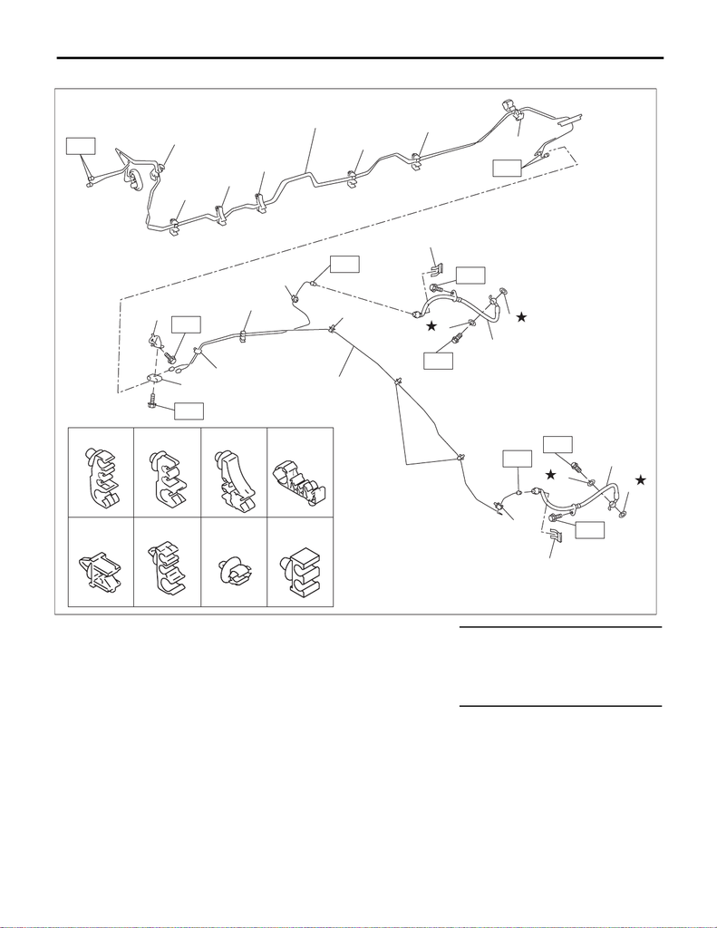

BR-11

General Description

BRAKE

5. CENTER AND REAR BRAKE PIPES AND HOSES

(1) Center brake pipe ASSY (5) Clamp Tightening torque: N·m (kgf-m, ft-lb)

(2) Bracket (6) Gasket T1: 15 (1.5, 11.1)

(3) Connector (7) Rear brake hose RH T2: 18 (1.8, 13.3)

(4) Rear brake pipe ASSY (8) Rear brake hose LH T3: 26 (2.7, 19.2)

T4: 33 (3.4, 24.3)

BR-01378

(1)

a

b

b

b

d

c

f

h

g

g

e

e

c

T1

T1

T1

T2

(3)

(2)

T1

(4)

abc d

ef gh

T1

T3

T4

(6)

(5)

(8)

(6)

T3

T4

(6)

(5)

(7)

(6)

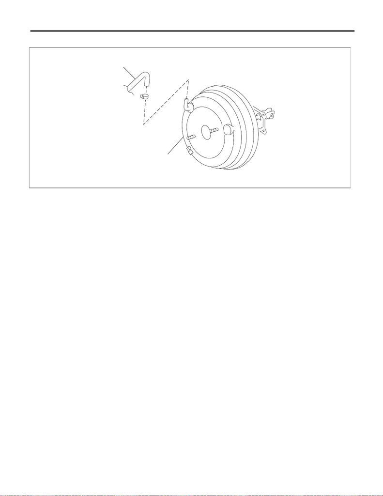

BR-12

General Description

BRAKE

6. BRAKE BOOSTER

(1) Vacuum booster ASSY (2) Vacuum hose

BR-01302

(1)

(2)

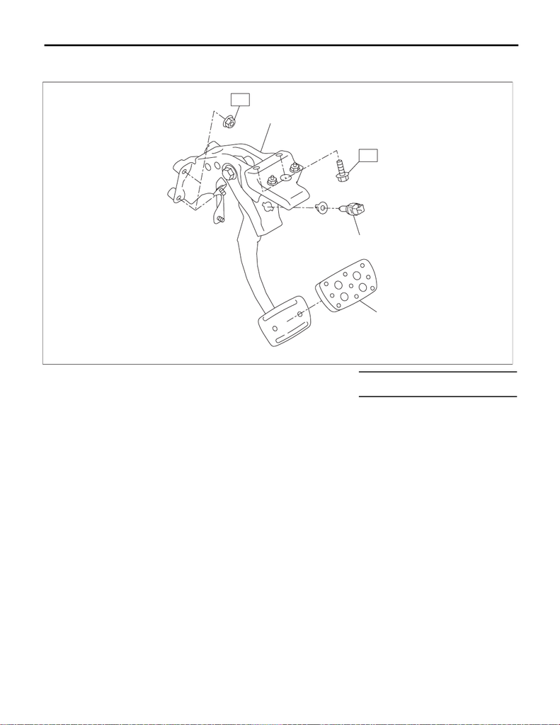

BR-13

General Description

BRAKE

7. BRAKE PEDAL

• AT model

(1) Brake pedal ASSY (3) Pad - brake pedal (sport type) Tightening torque: N·m (kgf-m, ft-lb)

(2) Stop light switch T: 18 (1.8, 13.3)

BR-01304

(2)

(1)

(3)

T

T

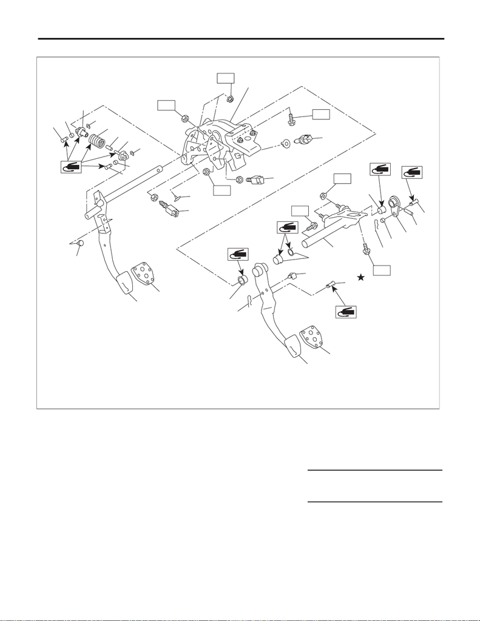

BR-14

General Description

BRAKE

•MT model

(1) Pedal bracket (10) Assist spring (19) Lever

(2) Stop light switch (11) Assist bushing (20) Snap pin

(3) Clutch switch (12) Assist rod A (21) Brake pedal

(4) Stopper (13) Clutch pedal (22) Pad - brake pedal (sport type)

(5) Clutch start switch (14) Pad - clutch pedal (sport type)

(6) Clutch clevis pin (15) Bushing Tightening torque: N·m (kgf-m, ft-lb)

(7) Bushing C (16) Clutch master cylinder bracket T1: 8 (0.8, 5.9)

(8) Assist rod B (17) Clevis pin T2: 18 (1.8, 13.3)

(9) Clip (18) Spring pin

CL-01042

(4)

(15)

(4)

(9)(7)

(8)

(10)

(11)

(9)

(12)

(5)

(3)

(1)

(2)

(4)

(17)

(20)

(7)

(18)

(17)

(22)

(21)

(20)

(13)

(14)

(15)

(19)

(16)

(15)

(6)

(7)

(6)

T1

T2

T2

T2

T2

T2

T1

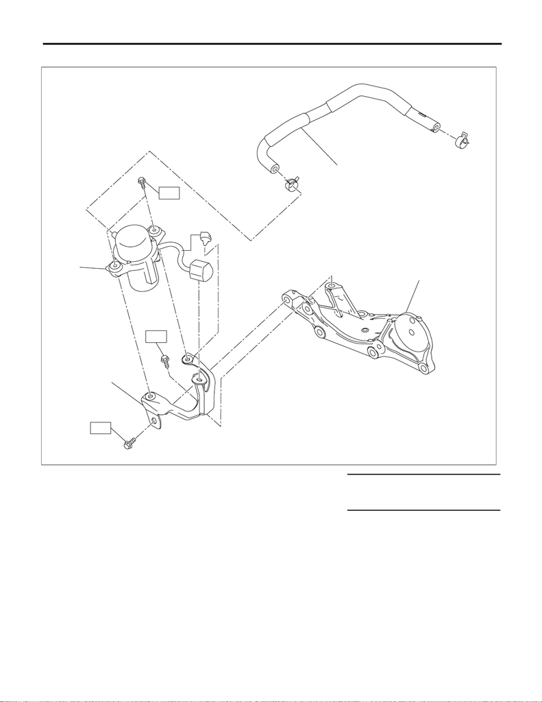

BR-15

General Description

BRAKE

8. BRAKE VACUUM PUMP

(1) Vacuum pump ASSY (3) Vacuum hose COMPL Tightening torque: N·m (kgf-m, ft-lb)

(2) Bracket COMPL - vacuum pump (4) Bracket - generator T1: 6.4 (0.7, 4.7)

T2: 19 (1.9, 14.0)

BR-01078

T1

T2

T2

(1)

(2)

(3)

(4)

[figure not shown]

BR-16

General Description

BRAKE

C: CAUTION

• When performing any work, always wear work clothes, a work cap and protective shoes. Additionally, wear

a helmet, protective goggles, etc. if necessary.

• When performing a repair, identify the cause of trouble and avoid unnecessary removal, disassembly and

replacement.

• Some vehicle components are extremely hot immediately after driving. Be wary of receiving burns from

heated parts.

• Use SUBARU genuine grease, the recommended or equivalent. Do not mix grease etc. of different grades

or manufacturers.

• Be sure to tighten fasteners including bolts and nuts to the specified torque.

• Always use the jack-up point when the shop jacks or rigid racks are used to support the vehicle.

• Apply grease onto sliding or revolving surfaces before installation.

• Be sure that the surface of brake disc, brake pad or brake shoe is free from grease or oil.

• Remove contamination including dirt and corrosion before removal, installation, disassembly or assembly.

• Do not secure a part in a vise directly. Place cushioning materials such as wood blocks, aluminum plates,

or waste cloth between the part and the vise.